# Clean workspace and load library

```r
rm(list=ls())
library(readr)
library(rvest)
library(dplyr)
```

```r
library(e1071)
library(ggplot2)
```

# Import and check data

the data is imported from World Happiness Report, available at https://www.kaggle.com/unsdsn/world-happiness/data

```r
raw_data <- read_csv("2015.csv")
dim(raw_data)
```

```
## [1] 158  12
```

```r
head(raw_data)
```

```
## # A tibble: 6 x 12
##       Country         Region `Happiness Rank` `Happiness Score`
##         <chr>          <chr>            <int>             <dbl>
## 1 Switzerland Western Europe                1             7.587
## 2     Iceland Western Europe                2             7.561
## 3     Denmark Western Europe                3             7.527
## 4      Norway Western Europe                4             7.522
## 5      Canada  North America                5             7.427
## 6     Finland Western Europe                6             7.406
## # ... with 8 more variables: `Standard Error` <dbl>, `Economy (GDP per
## #   Capita)` <dbl>, Family <dbl>, `Health (Life Expectancy)` <dbl>,
## #   Freedom <dbl>, `Trust (Government Corruption)` <dbl>,
## #   Generosity <dbl>, `Dystopia Residual` <dbl>
```

The data has 158 rows and 12 columns, showing happiness score and other information for 158 countries. In particular, each country has a happiness score and scores for 6 factors: economic production, social support, life expectancy, freedom, absence of corruption, and generosity. The country with the lowest national average for a factor receives 0 for that factor, and the score other countries received for that factor is the extent to which they outperform the country with the lowest national average.

```r
summary(raw_data)
```

```
##    Country             Region          Happiness Rank   Happiness Score
##  Length:158         Length:158         Min.   :  1.00   Min.   :2.839
##  Class :character   Class :character   1st Qu.: 40.25   1st Qu.:4.526
##  Mode  :character   Mode  :character   Median : 79.50   Median :5.232
##                                        Mean   : 79.49   Mean   :5.376
##                                        3rd Qu.:118.75   3rd Qu.:6.244
##                                        Max.   :158.00   Max.   :7.587
##  Standard Error    Economy (GDP per Capita)     Family
##  Min.   :0.01848   Min.   :0.0000           Min.   :0.0000
##  1st Qu.:0.03727   1st Qu.:0.5458           1st Qu.:0.8568
##  Median :0.04394   Median :0.9102           Median :1.0295
##  Mean   :0.04788   Mean   :0.8461           Mean   :0.9910
##  3rd Qu.:0.05230   3rd Qu.:1.1584           3rd Qu.:1.2144
##  Max.   :0.13693   Max.   :1.6904           Max.   :1.4022
##  Health (Life Expectancy)    Freedom       Trust (Government Corruption)
##  Min.   :0.0000           Min.   :0.0000   Min.   :0.00000
##  1st Qu.:0.4392           1st Qu.:0.3283   1st Qu.:0.06168
##  Median :0.6967           Median :0.4355   Median :0.10722
##  Mean   :0.6303           Mean   :0.4286   Mean   :0.14342
##  3rd Qu.:0.8110           3rd Qu.:0.5491   3rd Qu.:0.18025
##  Max.   :1.0252           Max.   :0.6697   Max.   :0.55191
##    Generosity     Dystopia Residual
##  Min.   :0.0000   Min.   :0.3286
##  1st Qu.:0.1506   1st Qu.:1.7594
##  Median :0.2161   Median :2.0954
##  Mean   :0.2373   Mean   :2.0990
##  3rd Qu.:0.3099   3rd Qu.:2.4624
##  Max.   :0.7959   Max.   :3.6021
```

The summary above shows that there is no missing value or unusual data. *** The original data is ordered by happiness score. Here, it is re-ordered by descending order of country name, which is a more arbitary ordering that can make the division of training and testing sets more random.

```r
raw_data <-  arrange(raw_data, desc(Country))
```

Dystopia Residual is the difference between the value of the six factors summed and the happiness score, and it is not related to this study. In addition, ‘Country’, ‘Happiness Rank’, ’Standard Error’are not relevant, so only relevant variables are selected, and they are renamed for convenience and Region shall be categorical.

```r
dataset1 <- raw_data %>% select (Region, 'Happiness Score', 'Economy (GDP per Capita)', Family, 'Health (Life Expectancy)', Freedom, 'Trust (Government Corruption)', Generosity)
dataset1 <- dataset1 %>% rename(Happiness_score = 'Happiness Score')
dataset1 <- dataset1 %>% rename(GDP_per_Capita = 'Economy (GDP per Capita)')
dataset1 <- dataset1 %>% rename(Life_expectancy = 'Health (Life Expectancy)')
dataset1 <- dataset1 %>% rename(Trust_in_Government = 'Trust (Government Corruption)')
dataset1$Region <- factor(dataset1$Region)
```

# Check for normality, outlier and correlation

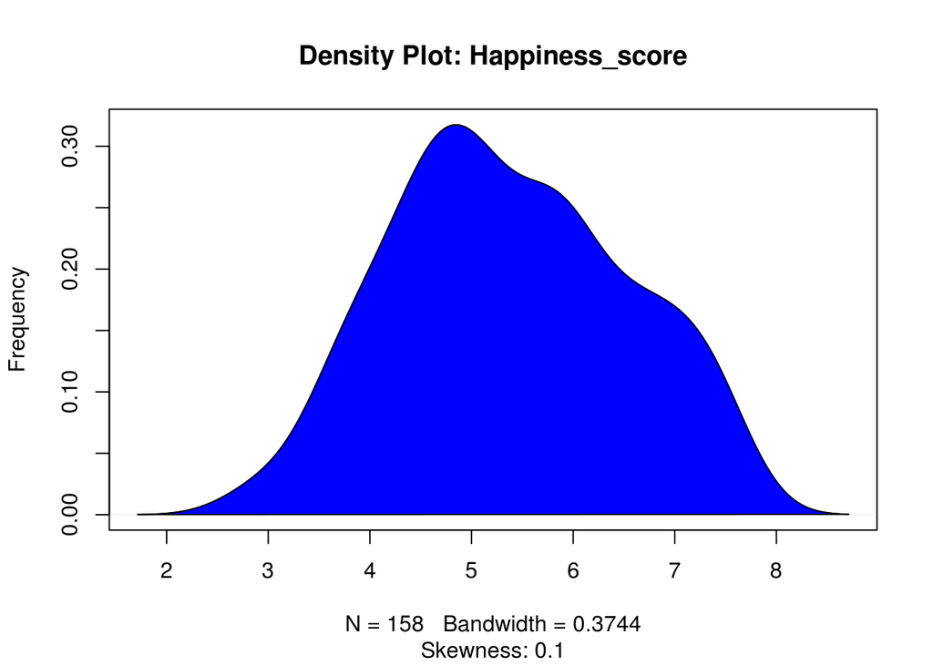

```r
plot(density(dataset1$Happiness_score), main="Density Plot: Happiness_score", ylab="Frequency", sub=paste("Skewness:", round(e1071::skewness(dataset1$Happiness_score), 2)))
polygon(density(dataset1$Happiness_score), col="blue")
```

The distribution of Happiness_score approximates normal with very low skewness.

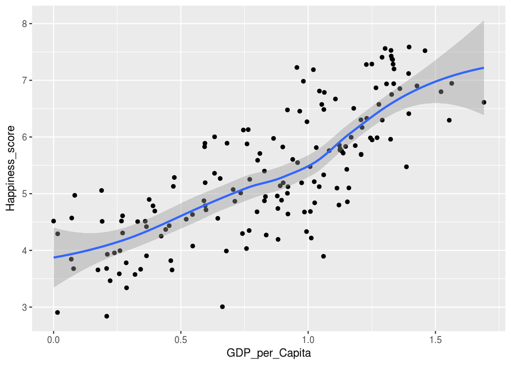

```r
ggplot(data = dataset1,aes(x = GDP_per_Capita, y = Happiness_score)) + geom_point() +geom_smooth()
```

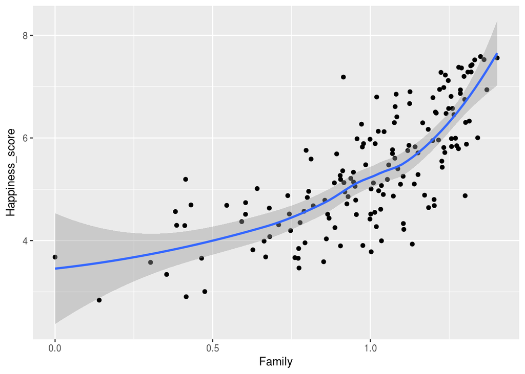

```r
ggplot(data = dataset1,aes(x = Family, y = Happiness_score)) + geom_point() +geom_smooth()
```

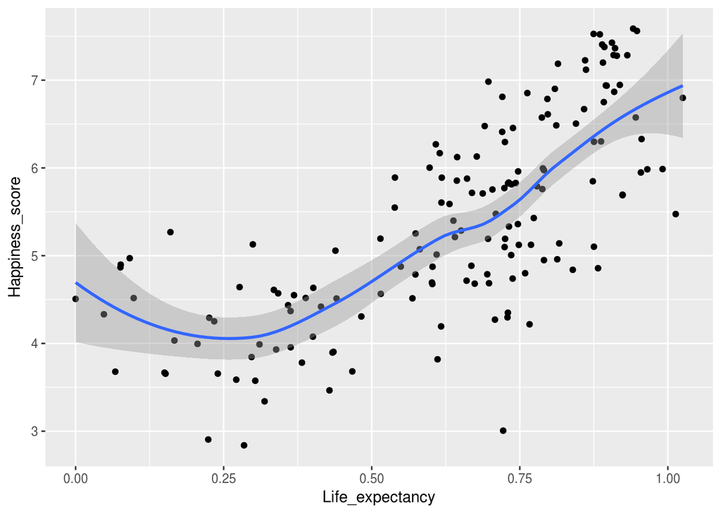

```r
ggplot(data = dataset1,aes(x = Life_expectancy, y = Happiness_score)) + geom_point() +geom_smooth()
```

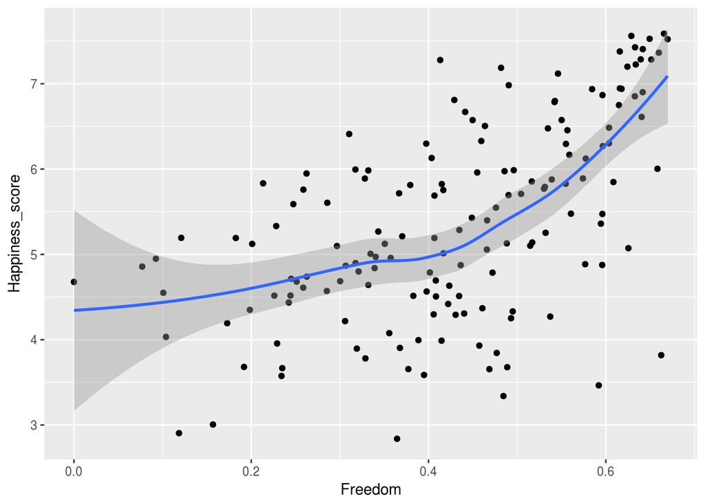

```r
ggplot(data = dataset1,aes(x = Freedom, y = Happiness_score)) + geom_point() +geom_smooth()
```

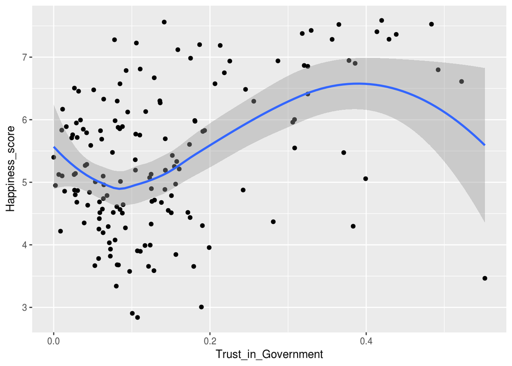

```r
ggplot(data = dataset1,aes(x = Trust_in_Government, y = Happiness_score)) + geom_point() +geom_smooth()
```

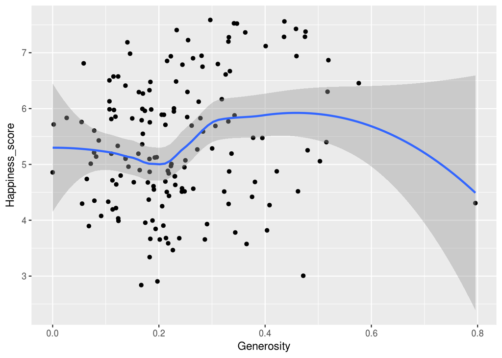

```r
ggplot(data = dataset1,aes(x = Generosity, y = Happiness_score)) + geom_point() +geom_smooth()
```

The above plots show that there is likely to be linear relationship between Happiness_score and some variables. Therefore, linear regression model can predict happiness score.

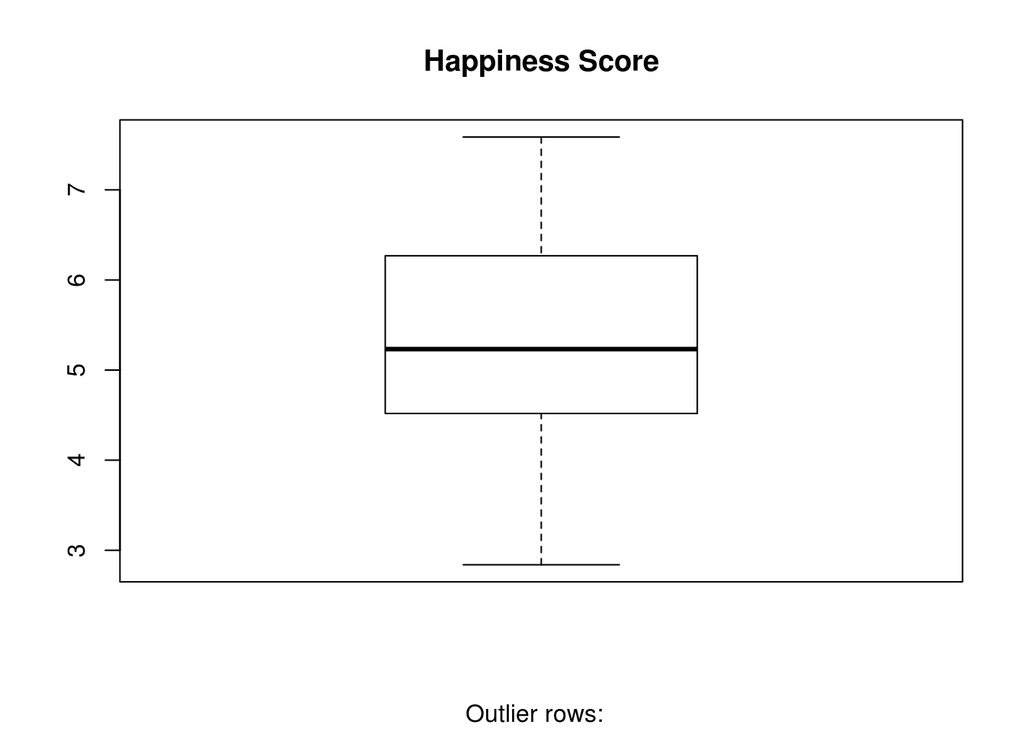

```r
boxplot(dataset1$Happiness_score, main="Happiness Score", sub=paste("Outlier rows: ", boxplot.stats(dataset1$Happiness_score)$out))
```

The graph shows that there is no outlier for Happiness_score.

To build a linear regression model and test the model, the data is subsetted with 80% used for training and 20% for testing.

```r
trainingData <- dataset1[1:126,]
testData <- dataset1[127:158,]
```

# The first linear regression model

```r
LM1 <- lm(Happiness_score ~ GDP_per_Capita + Family + Life_expectancy + Freedom + Trust_in_Government + Generosity + Region, trainingData)
summary(LM1)
```

```
##
## Call:
## lm(formula = Happiness_score ~ GDP_per_Capita + Family + Life_expectancy +
##     Freedom + Trust_in_Government + Generosity + Region, data = trainingData)
##
## Residuals:
##      Min       1Q   Median       3Q      Max
## -1.37571 -0.27476 -0.00069  0.34464  1.25742
##
## Coefficients:
##                                        Estimate Std. Error t value
## (Intercept)                            2.933556   0.751450   3.904
## GDP_per_Capita                         1.087657   0.262247   4.147
## Family                                 1.267937   0.285769   4.437
## Life_expectancy                        0.216816   0.507864   0.427
## Freedom                                0.890266   0.483919   1.840
## Trust_in_Government                    0.879686   0.492079   1.788
## Generosity                             0.369827   0.481265   0.768
## RegionCentral and Eastern Europe      -0.514547   0.586611  -0.877
## RegionEastern Asia                    -0.771543   0.608305  -1.268
## RegionLatin America and Caribbean      0.003521   0.586368   0.006
## RegionMiddle East and Northern Africa -0.558262   0.586003  -0.953
## RegionNorth America                    0.126366   0.773792   0.163
## RegionSoutheastern Asia               -0.504214   0.594680  -0.848
## RegionSouthern Asia                   -0.452545   0.647217  -0.699
## RegionSub-Saharan Africa              -0.677809   0.625486  -1.084
## RegionWestern Europe                  -0.269759   0.562910  -0.479
##                                       Pr(>|t|)
## (Intercept)                           0.000164 ***
## GDP_per_Capita                        6.64e-05 ***
## Family                                2.18e-05 ***
## Life_expectancy                       0.670274
## Freedom                               0.068509 .
## Trust_in_Government                   0.076579 .
## Generosity                            0.443868
## RegionCentral and Eastern Europe      0.382315
## RegionEastern Asia                    0.207351
## RegionLatin America and Caribbean     0.995220
## RegionMiddle East and Northern Africa 0.342851
## RegionNorth America                   0.870576
## RegionSoutheastern Asia               0.398349
## RegionSouthern Asia                   0.485892
## RegionSub-Saharan Africa              0.280889
## RegionWestern Europe                  0.632732
## ---
## Signif. codes:  0 '***' 0.001 '**' 0.01 '*' 0.05 '.' 0.1 ' ' 1
##
## Residual standard error: 0.5385 on 110 degrees of freedom
## Multiple R-squared:  0.7837, Adjusted R-squared:  0.7542
## F-statistic: 26.56 on 15 and 110 DF,  p-value: < 2.2e-16
```

```r
AIC_1 <- AIC(LM1)
BIC_1 <- BIC(LM1)
cat("AIC: ", AIC_1, '\n')
```

```
## AIC:  218.4939
```

```r
cat("BIC: ", BIC_1, '\n')
```

```
## BIC:  266.7107
```

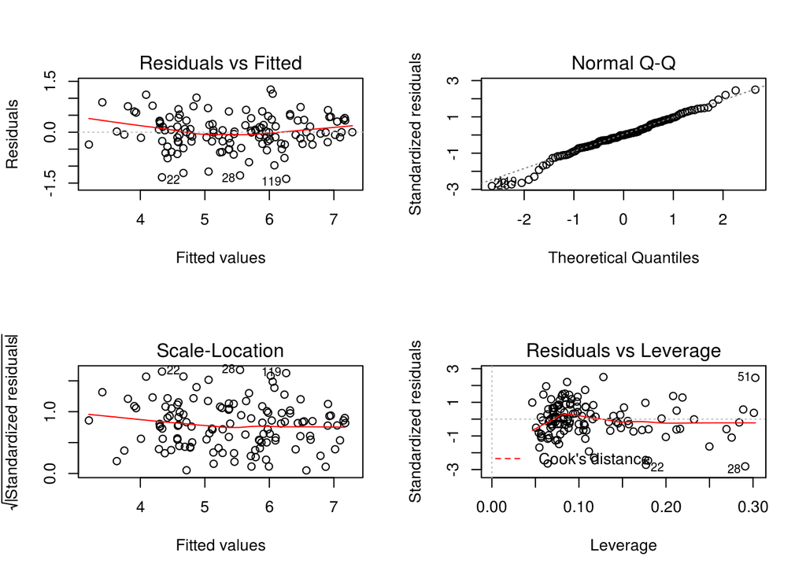

```r
par(mfrow=c(2, 2))
plot(LM1)
```

Multiple R-squared and Adjusted R-squared are above 0.7, p-value is close to zero, so the model is generally fine and the residual plots are relatively flat

# Test the first model

```r
happinessPred <- predict(LM1, testData)
actuals_preds <- data.frame(cbind(actuals = testData$Happiness_score, predicteds = happinessPred))
correlation_accuracy <- cor(actuals_preds)
min_max_accuracy <- mean(apply(actuals_preds, 1, min) / apply(actuals_preds, 1, max))
mape <- mean(abs((actuals_preds$predicteds - actuals_preds$actuals))/actuals_preds$actuals)
head(actuals_preds)
```

```
##   actuals predicteds
## 1   3.989   4.419508
## 2   3.956   4.043212
## 3   6.477   6.247532
## 4   5.140   5.022601
## 5   6.670   6.382670
## 6   3.667   3.948181
```

```r
cat('Correlation accuracy: ',correlation_accuracy[2],'\n')
```

```
## Correlation accuracy:  0.9461254
```

```r
cat('Min-Max Accuracy: ', min_max_accuracy,'\n')
```

```
## Min-Max Accuracy:  0.9312811
```

```r
cat('Mean absolute percentage error',mape,'\n')
```

```
## Mean absolute percentage error 0.07576663
```

The accuracy of prediction is very high. We will continue to build the second regression model with only statistically significant variables to see if it can perform even better.

# The second linear regression model

```r
LM2 <- lm(Happiness_score ~ GDP_per_Capita + Family + Freedom + Trust_in_Government, trainingData)
summary(LM2)
```

```
##
## Call:
## lm(formula = Happiness_score ~ GDP_per_Capita + Family + Freedom +
##     Trust_in_Government, data = trainingData)
##
## Residuals:
##      Min       1Q   Median       3Q      Max
## -1.46405 -0.31474  0.02936  0.35732  1.54797
##
## Coefficients:
##                     Estimate Std. Error t value Pr(>|t|)
## (Intercept)           2.1901     0.2178  10.056  < 2e-16 ***
## GDP_per_Capita        1.2942     0.1564   8.273 1.98e-13 ***
## Family                1.3609     0.2683   5.073 1.43e-06 ***
## Freedom               1.5497     0.4469   3.468 0.000727 ***
## Trust_in_Government   0.6430     0.4753   1.353 0.178657
## ---
## Signif. codes:  0 '***' 0.001 '**' 0.01 '*' 0.05 '.' 0.1 ' ' 1
##
## Residual standard error: 0.5632 on 121 degrees of freedom
## Multiple R-squared:  0.7398, Adjusted R-squared:  0.7312
## F-statistic: 85.99 on 4 and 121 DF,  p-value: < 2.2e-16
```

```r
AIC_2 <- AIC(LM2)
BIC_2 <- BIC(LM2)
cat("AIC: ", AIC_2, '\n')
```

```
## AIC:  219.7718
```

```r
cat("BIC: ", BIC_2, '\n')
```

```
## BIC:  236.7895
```

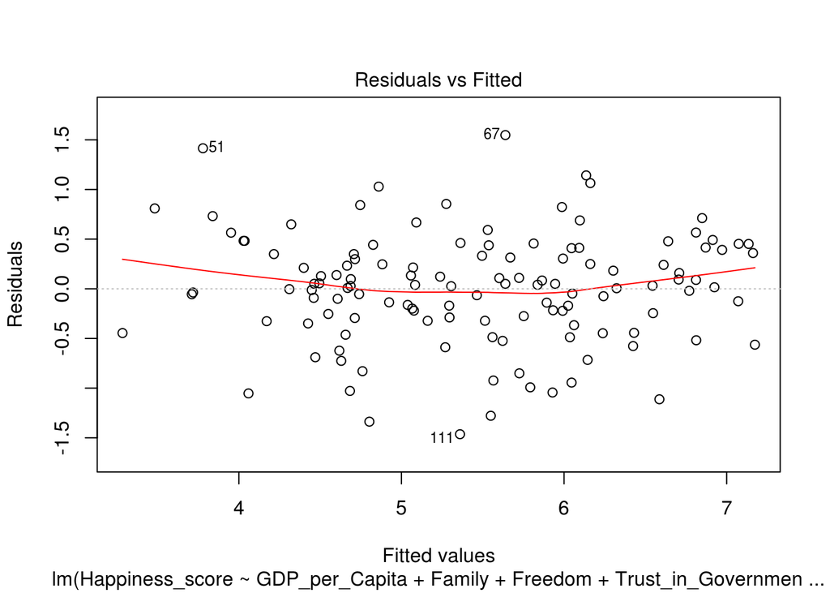

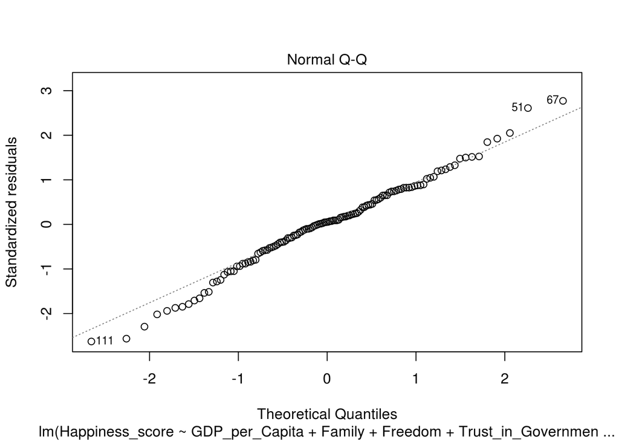

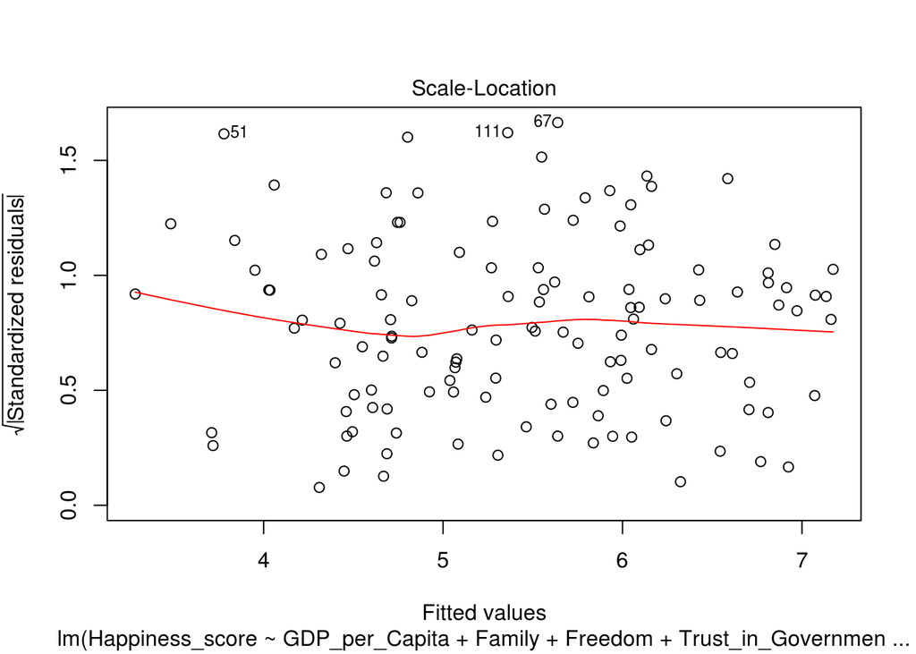

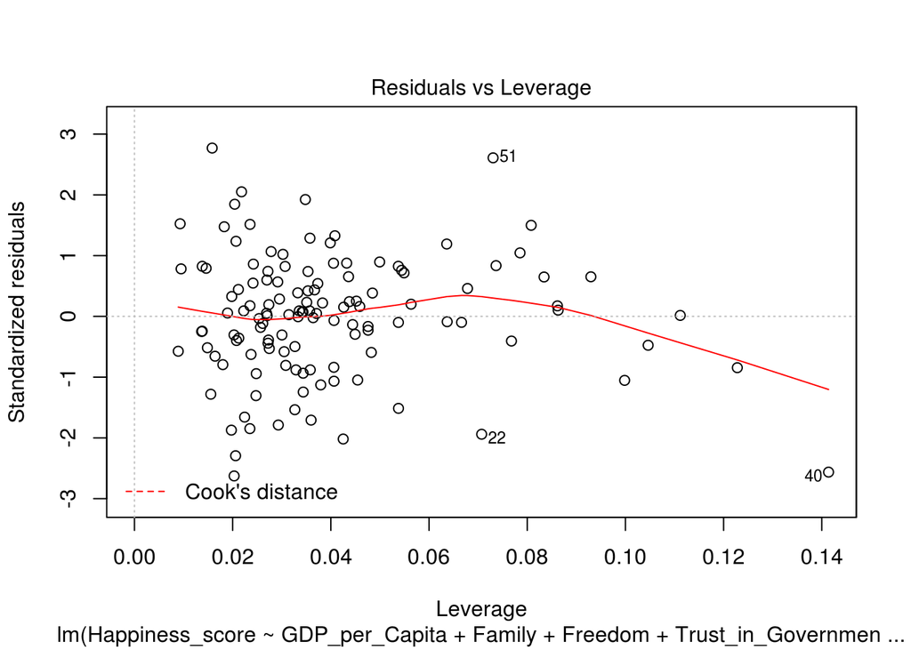

```r
plot(LM2)
```

Multiple R-squared and Adjusted R-squared are above 0.7, p-value is close to zero and almost flat residual plots show that the model works well

# test of the second model

```r
happinessPred2 <- predict(LM2, testData)
actuals_preds2 <- data.frame(cbind(actuals = testData$Happiness_score, predicteds = happinessPred2))
correlation_accuracy2 <- cor(actuals_preds2)
min_max_accuracy2 <- mean(apply(actuals_preds2, 1, min) / apply(actuals_preds2, 1, max))
mape2 <- mean(abs((actuals_preds2$predicteds - actuals_preds2$actuals))/actuals_preds2$actuals)
head(actuals_preds2)
```

```
##   actuals predicteds
## 1   3.989   4.688219
## 2   3.956   4.061358
## 3   6.477   5.928107
## 4   5.140   5.449458
## 5   6.670   5.919820
## 6   3.667   4.065765
```

```r
cat('Correlation accuracy: ',correlation_accuracy2[2],'\n')
```

```
## Correlation accuracy:  0.8966952
```

```r
cat('Min_Max Accuracy: ', min_max_accuracy2,'\n')
```

```
## Min_Max Accuracy:  0.9061828
```

```r
cat('Mean absolute percentage error: ',mape2,'\n')
```

```
## Mean absolute percentage error:  0.1046679
```

# Conclusion

In comparison, the first model has smaller AIC, higher Multiple R-squared and Adjusted R-squared, higher correlation accuracy, higher Min_Max Accuracy, and lower Mean absolute percentage error, so the first model is better in predicting happiness level. So the first model is chosen.

A prediction function and a Shiny application are built with this regression model.